# Homework 07

## Question 4: Create and use an LDA/QDA analysis skill

In Homework 5, you created a skill for formatting plots. Now create a reusable skill that guides an AI agent through an LDA/QDA analysis and produces a concise statistical report. You may work with AI to design and write the skill; you do not need to write every line yourself.

1. **Define the skill.** Write a single `SKILL.md` file no larger than **5 KB (5,000 bytes)**. Define the agent’s behavior, analysis guidelines, and expected report structure. Keep the skill independent of this question: provide the dataset, response, and predictors separately when invoking it. The skill may guide the agent to explore lower-dimensional representations, such as principal component analysis (PCA), or to blend the class probabilities predicted by LDA and QDA. Keep all classifiers based on LDA, QDA, or their combination. Configure the skill to load **only when you explicitly invoke it**. Use your AI tool’s invocation settings, or keep the file outside automatically loaded skill folders and supply it only in an explicit request.

Your skill must require a clearly readable analysis report of **at most one printed page**, containing a figure, a table, and numerical model-fitting results. You may specify the type and style of figures and tables you want the AI to produce. All instructions in the skill must be independent of the actual dataset, its variable names, and its observed results. The report should briefly describe the candidate models, the cross-validation procedure and results, the selected model, and its estimated prediction error. It should explain the main findings and any limitations.

2. **Apply the skill.** Explicitly invoke your skill to analyze the `SAheart` data from Question 1, using the same response and predictor coding. Ask the agent to seek the best predictive performance within the LDA/QDA methods allowed by your skill. Include ordinary LDA and QDA as comparisons; the extensions above are optional. Reserve a test set before choosing models. Use the same cross-validation folds within the training data to compare candidates and select any settings. Estimate any preprocessing, including an embedding, using only the training observations in each fold. Refit the selected model and preprocessing on all training observations, then evaluate the fitted classifier once on the reserved test set. Use misclassification rate to compare performance, and report your random seed.
3. **Review and submit.** Check the agent’s analysis and make any skill revisions using only training and cross-validation results. Append the final one-page analysis report and the complete contents of your `SKILL.md` to your homework report. State the file size and briefly explain how you enabled explicit invocation, including the prompt used to apply the skill. The one-page limit applies to the analysis report; the appended skill and this explanation are outside that limit.

Your skill and analysis report will be reviewed and graded by other students through peer evaluation.

# One-page report

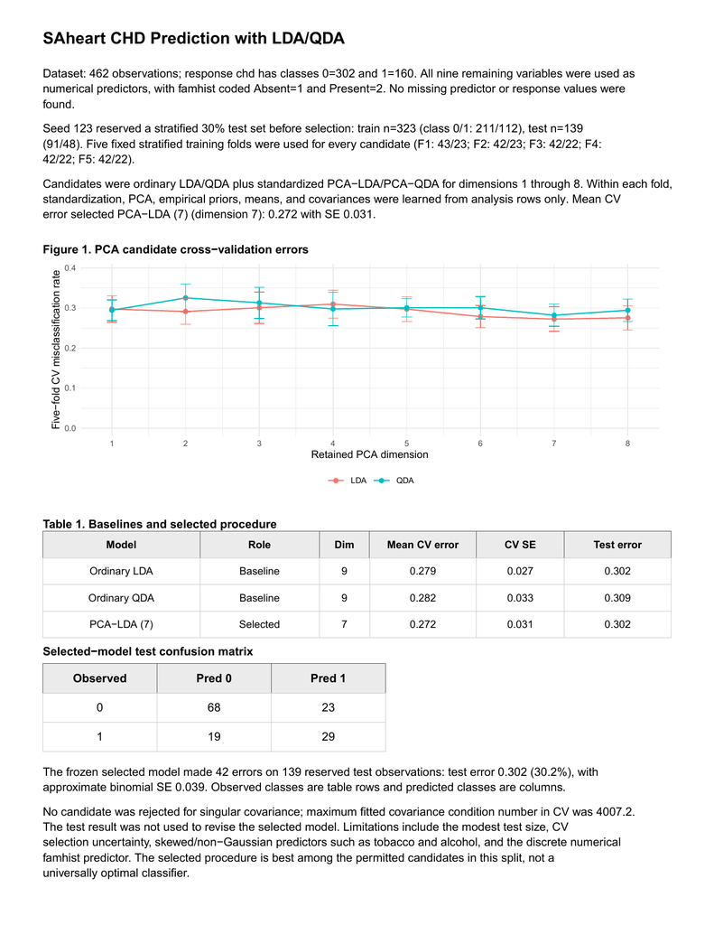

#Prompt Explicitly read and invoke homework/week-07/SKILL.md. Follow its analysis workflow and reporting requirements, and use R throughout.  
Analyze data/saheart.csv with chd as the response and all nine remaining variables as numerical predictors. Code famhist as 1 for Absent and 2 for Present. Use random seed 123. Seek the best predictive performance among the LDA/QDA methods permitted by the skill. Include ordinary LDA and ordinary QDA as baseline comparisons. Reserve a test set before model selection. Use identical cross-validation folds within the training data to compare candidates. Estimate all preprocessing, including standardization and PCA if used, using only the analysis observations in each fold. Select the model using cross-validation misclassification rate, refit the selected procedure on all training observations, and evaluate it once on the reserved test set. Do not revise the skill or model selection based on test results. Run the R code and provide: 1. A final one-page English analysis report meeting the skill requirements, including a figure, a table, and numerical model-fitting results. 2. A separate reproducible R script. 3. The exact size of SKILL.md in bytes. If R cannot be run, state this clearly. Do not invent results or substitute Python results.